# Wiedza i normy - efekt Knobe’a i zaniechaniowa koncepcja intencjonalności - raport z badania

## Autorzy badania: Sławomir Mijas, Ignacy Szczeniowski

## Cel badania:

Sprawdzenie zaniechaniowego wyjaśnienia efektu Knobe’a zaproponowanego przez prof. Katarzynę Paprzycką.

## Konstrukcja badania:

Badanym przedstawiony były oryginalne Knobe’owskie scenariusze:

**Scenariusz HARM**

Wicedyrektor zwraca się do dyrektora pewnej firmy:

„Myślimy o wdrożeniu nowego programu. Pozwoli nam zwiększyć zyski, ale zaszkodzi środowisku”.

Dyrektor odpowiada:

„Nie obchodzi mnie szkodzenie środowisku. Chcę tylko zwiększyć zyski. Wdrażamy program”.

Program został wdrożony i rzeczywiście zaszkodził środowisku.

**Scenariusz HELP**

Wicedyrektor zwraca się do dyrektora pewnej firmy:

„Myślimy o wdrożeniu nowego programu. Pozwoli nam zwiększyć zyski i pomoże środowisku”.

Dyrektor odpowiada:

„Nie obchodzi mnie pomaganie środowisku. Chcę tylko zwiększyć zyski. Wdrażamy program”.

Program został wdrożony i rzeczywiście pomógł środowisku.

Następnie zostały zadane im trzy pytania (każde na osobnym ekranie, bez możliwości powrotu do poprzedniego pytania)

1. Czy dyrektor umyślnie zaszkodził/pomógł środowisku? (intencjonalność)
2. Czy dyrektor wiedział, że ma obowiązek nie szkodzić/pomóc środowisku? (wiedza o obowiązku)
3. Czy dyrektor miał obowiązek nie szkodzić/pomóc środowisku? (istnienie obowiązku)

## Technikalia

Każdemu z badanych zaprezentowany był tylko jeden scenariusz. Czas na odpowiedź był nieograniczony. Badanie odbyło się za pośrednictwem internetowego systemu ankietowego Limesurvey na platformie uniwersyteckiej Kognilab.

## Wyniki:

### Czy dyrektor umyślnie zaszkodził/pomógł środowisku? (intencjonalność)

```
##               GROUP
## intentionality Harm Help
##            0      0    0
##            Nie   11   54
##            Tak   53    8
```

#### Test istotności statystycznej:

```
##
##  Pearson's Chi-squared test with Yates' continuity correction
##
## data:  GROUP and intentionality
## X-squared = 58.859, df = 1, p-value = 1.694e-14
```

#### Wykres:

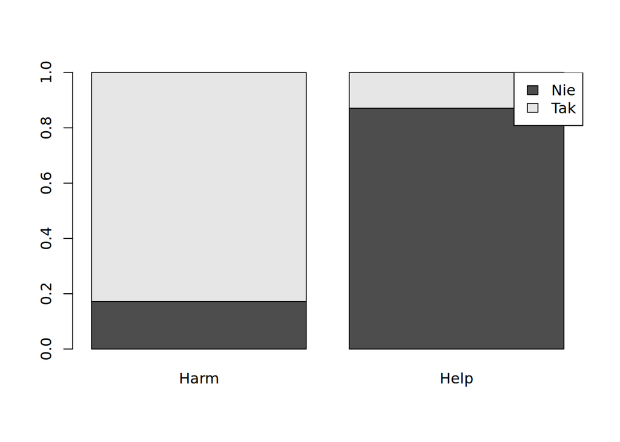

### Czy dyrektor wiedział, że ma obowiązek nie szkodzić/pomóc środowisku? (wiedza o obowiązku)

```
##                GROUP
## obligation_know Harm Help
##             0      0    0
##             Nie   34   50
##             Tak   30   12
```

#### Test istotności statystycznej:

```
##
##  Pearson's Chi-squared test with Yates' continuity correction
##
## data:  GROUP and obligation_know
## X-squared = 9.5302, df = 1, p-value = 0.002021
```

#### Wykres:

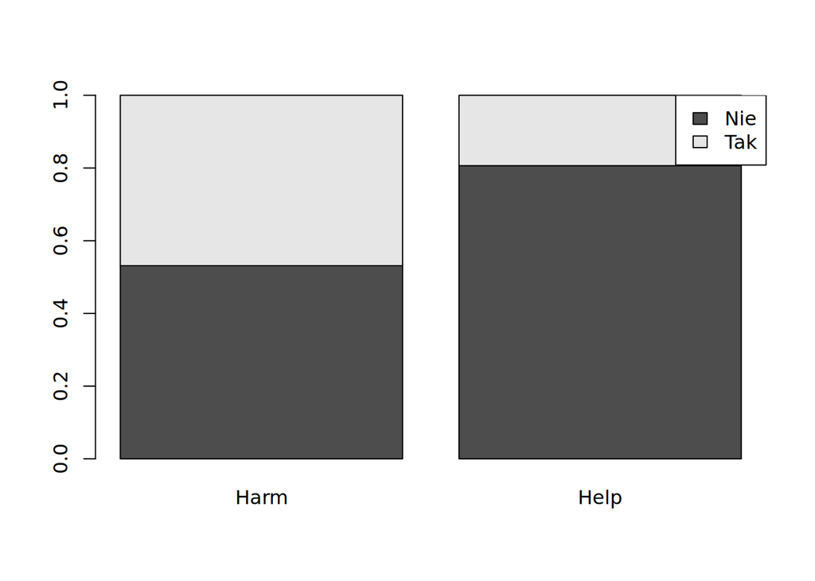

### Czy dyrektor miał obowiązek nie szkodzić/pomóc środowisku? (istnienie obowiązku)

```
##                 GROUP
## obligation_exist Harm Help
##              0      0    0
##              Nie   30   45
##              Tak   34   17
```

#### Test istotności statystycznej:

```
##
##  Pearson's Chi-squared test with Yates' continuity correction
##
## data:  GROUP and obligation_exist
## X-squared = 7.6031, df = 1, p-value = 0.005827
```

#### Wykres:

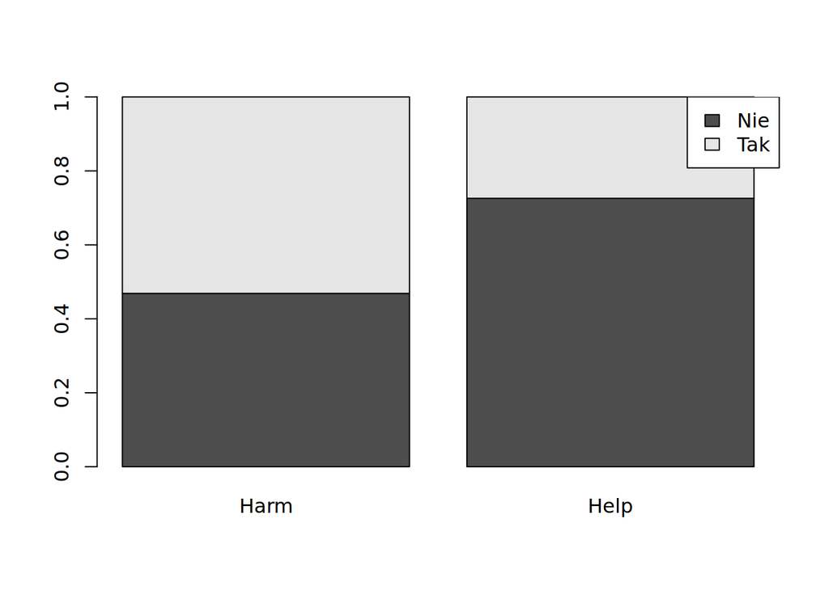